# Ford GoBike System Data

## by Faisal AlFaqih

## Investigation Overview

> Formerly known as Ford GoBikes, renamed Lyft Bikes is a regional public bicycle sharing system in the San Francisco Bay Area, California.My overall goals are: find which days the costomer and the subscribers use the bike the most and comber between them and find the mean duration dor both of them .

## Dataset Overview

> This data set had information about individual rides made in a bike-sharing system covering the greater San Francisco Bay area.The source data (Ford GoBike System Data) is available at : https://www.fordgobike.com/system-data.

The Features included in the Data are as follows :

- Member Year of Birth -Member Gender -User Type (Subscriber or Customer – “Subscriber” = Member or “Customer” = Casual) -Trip Duration(in seconds) -Bike ID -Start Time and Date -End Time and Date -Start Station ID -End Station ID -Start Station Name -End Station Name -End Station Latitude -End Station Longitude -Start Station Latitude -Start Station Longitude

## Who are the most Ford GoBike users? Ary they Customers or Subscribers?

> Here we find that 89.2% of the user types in the Ford GoBikes sharing platform were Subscribers. 10.8% of the user types in the Ford GoBikes Sharing Platform were Customers.

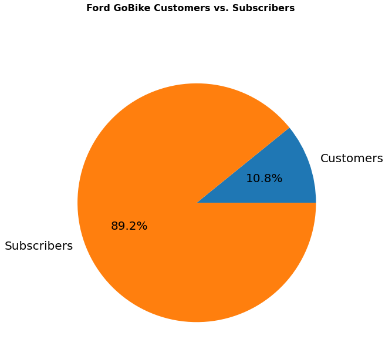

## Which days of the week do they ride the bikes the longest duration?

> in sunday and saturday the most days they uses the bike for more than 800 sec , the otherdays at usually used less than 800 sec.

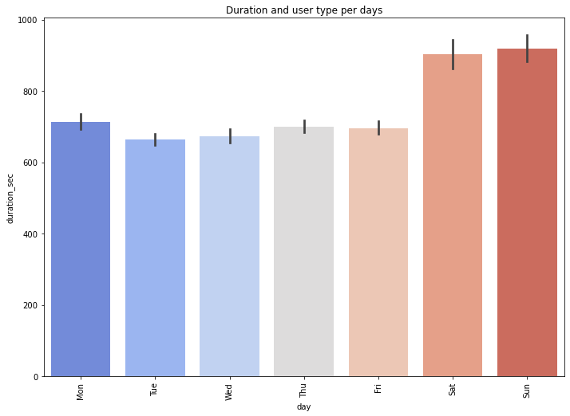

## What is the Distribution of trip duartion across user type in different days?

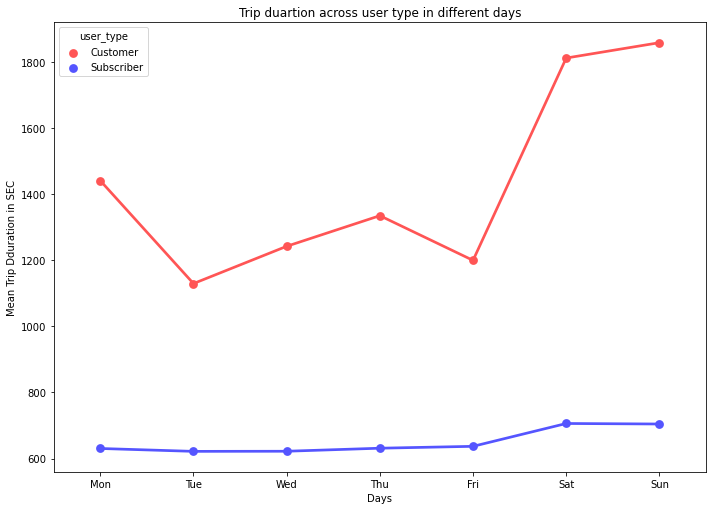